# EVAR statistics, Forth Valley Royal Hospital

Martin Hennessy

# Introduction

- Endovascular aneurysm repair (EVAR) of abdominal aortic aneurysms (AAA) is a less invasive method of excluding these aneurysms from the circulation than open repair.
- The aim of aneurysm repair is to prevent death from aneurysm rupture.
- EVAR has been performed in Forth Valley Royal Hospital (FVRH) since 2013-10-08.
- It has been 1822 days (60 months) since the first EVAR.
- In that time, 49 have been performed.
- That translates to a rate of one EVAR every 37 days.

# Demographics

## Gender & Age

Basic gender and age data are contained in the table below:

| Parameter | Number |
| --- | --- |
| Women | 3 |
| Men | 46 |
| Youngest | 61 |
| Oldest | 85 |
| Mean | 74 |

## Indications

Of the 49 performed, the indications are listed in the table below:

| Indication | Number |
| --- | --- |
| Unruptured AAA | 46 |
| Common iliac artery aneurysm | 2 |
| Mycotic pseudo/aneurysm | 1 |

- For unruptured AAA the majority are performed in an elective manner.
- Occasionally, a symptomatic patient will have EVAR as an inpatient.
- There is no out of hours/emergency provision of EVAR at FVRH.

### EVAR for unruptured AAA

**THE REMAINDER OF THE DOCUMENT FOCUSES ON THE EVAR FOR UNRUPTURED AAA ONLY**

EVAR for unruptured AAA has been performed on AAA from 46 mm to 88 mm (mean 59 mm.)

The distribution of AAA sizes is below:

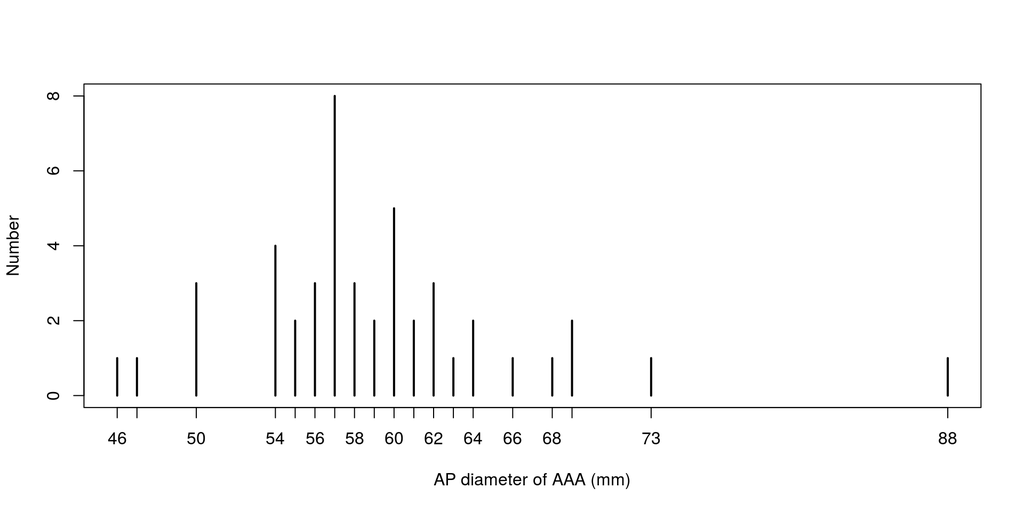

# EVAR planning, practice and admission lengths

## Planning CT

- Recent imaging is essential in planning successful EVAR
- The number of days between CT and EVAR has ranged from 7 to 324 with a mean of 74 days.

## Type of EVAR

- EVAR is a varied procedure, with conventional landing zones being in both CIAs.
- EVARs can also land in one or both external iliac arteries (EIA), can involve only one iliac system (aorto-uni-iliac, AUI) or can branch in to both EIA and internal iliac artery (iliac branch, IBE)
- The frequency of each of those is shown below:

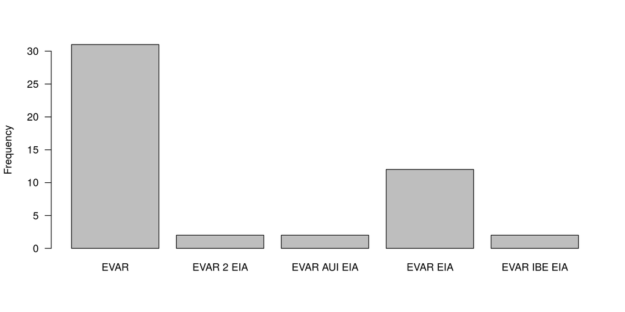

## Choice of stent-graft

- Different stent-grafts are available (and used) for EVAR:

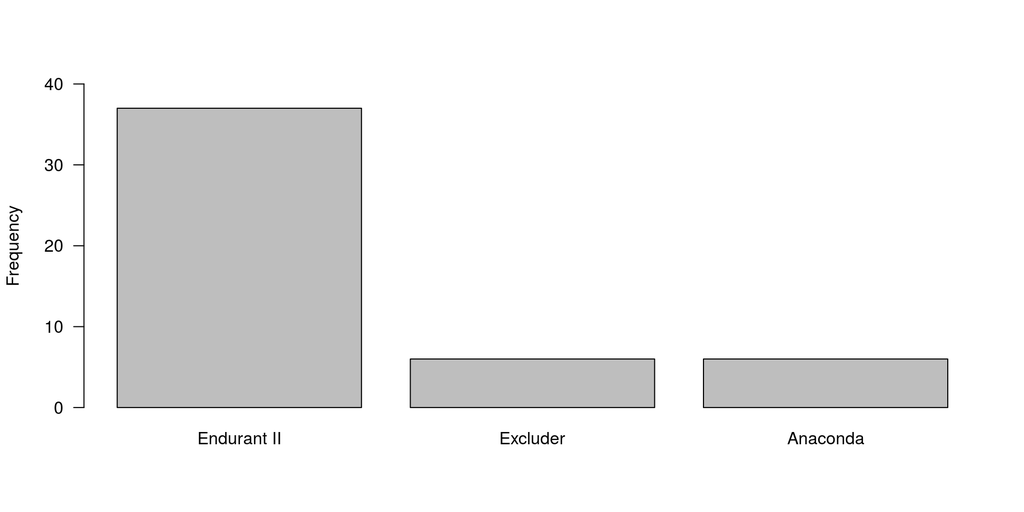

## Access method

- Access to the common femoral arteries can be obtained by a surgical cut-down or by a percutaneous puncture.
- The percutaneous method requires the use of a closure device which is able to achieve haemostasis at the end of the procedure.
- The first percutaneous EVAR was performed on 2017-12-15.
- Since then, 11 percutaneous EVARs have been performed. This compares to the total number of open EVARs as below:

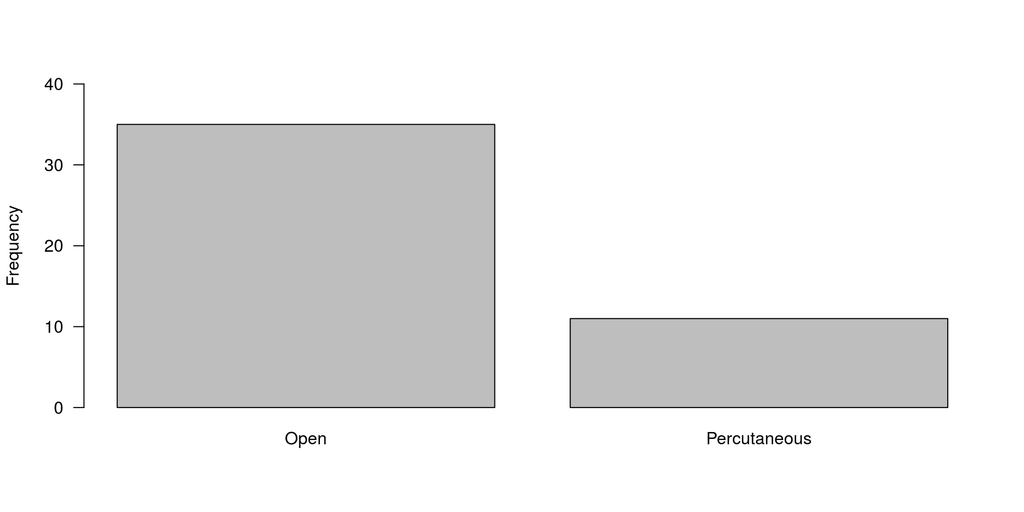

* A perceived advantage to percutaneous EVAR is that the lack of surgical wound will decrease admission lengths. * The spread of overall admission lengths is shown here:

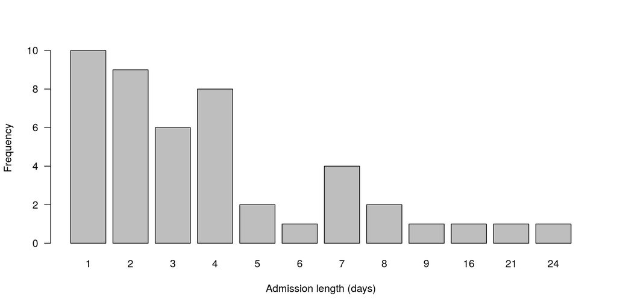

- A boxplot showing the admission lengths for open (left) and percutaneous (right) access is shown below. Student’s t-test shows the difference in the mean admission length to be significantly different between the two groups:

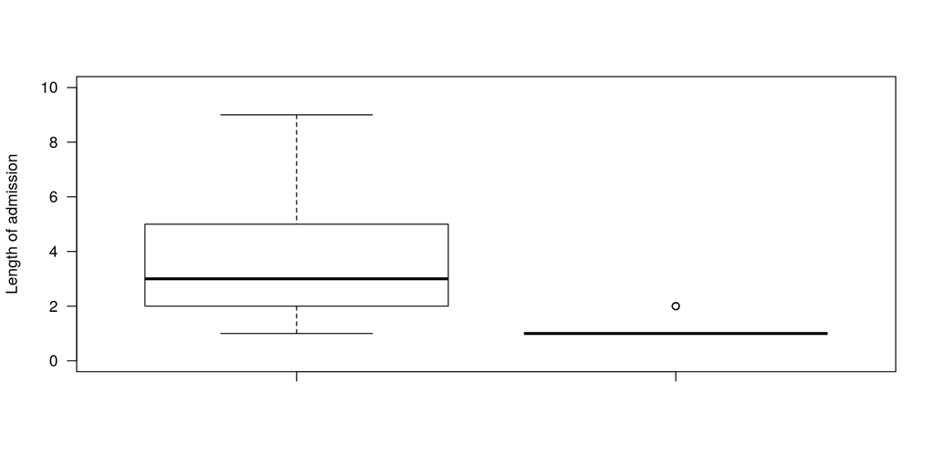

# EVAR post-procedure

## Mortality and survival

- Overall mortality of patients who have had EVAR is 17%.
- Due to the short era of EVAR in FVRH, survival curves are not robust but the median survival is at least 738 days.
- This is the survival of the patient who has died the longest time since EVAR.
- Median survival usually represents the period of time at which 50% of subjects have died but as only 17% have died then this figure is the current surrogate.
- This unattractive Kaplan-Meier curve highlights the lack of data with its large vertical steps:

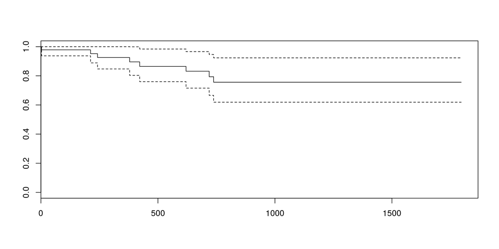

## Graft thrombosis

- Graft thrombosis is a major complication after EVAR. Usually, a single limb thromboses in isolation first.
- Limb thrombosis has occurred 2 times, a rate of 4%.

## Re-intervention

- If the aneurysmal sac continues to enlarge because of endoleak, re-intervention may be required.
- Type 2 endoleak is the most common.
- 3 type 2 endoleak procedures have been performed, a rate of 7%.